# SpamPredictor

## Objective

We will be building a SMS spam detector. With the input data we have to train the model, a file containing sms data and the classification label. Using this we shall build a Naive Bayes classifier model which will detect sms to be ham/spam.

## Importing All libraries

```python
import pandas as pd
%matplotlib inline

import warnings
warnings.filterwarnings('ignore')
```

## Step 1: Importing data set with separator as Tab

```python
msg=pd.read_csv('F:\pythonProject\Vignesh Programming\Spam Detector\SMSSpamCollection',sep='\t',names=['label','msgs'])
msg.tail()
```

|  | label | msgs |
| --- | --- | --- |
| 5567 | spam | This is the 2nd time we have tried 2 contact u... |
| 5568 | ham | Will ü b going to esplanade fr home? |
| 5569 | ham | Pity, * was in mood for that. So...any other s... |
| 5570 | ham | The guy did some bitching but I acted like i'd... |
| 5571 | ham | Rofl. Its true to its name |

## Step 2: Exploratory Data Analysis

Let us see the summary based on the labels column. group by label column and call describe function.

```python
msg.groupby('label').describe()
```

| label | msgs count | msgs unique | msgs top | msgs freq |
| --- | --- | --- | --- | --- |
| ham | 4825 | 4516 | Sorry, I'll call later | 30 |
| spam | 747 | 653 | Please call our customer service representativ... | 4 |

## Step 3: Data Visualization

Let us plot the length distribution of the sms across labels.

```python
msg['length']=msg['msgs'].apply(len)
msg.tail()
```

|  | label | msgs | length |
| --- | --- | --- | --- |
| 5567 | spam | This is the 2nd time we have tried 2 contact u... | 160 |
| 5568 | ham | Will ü b going to esplanade fr home? | 36 |
| 5569 | ham | Pity, * was in mood for that. So...any other s... | 57 |
| 5570 | ham | The guy did some bitching but I acted like i'd... | 125 |
| 5571 | ham | Rofl. Its true to its name | 26 |

```python
msg['length'].describe()
```

```
count    5572.000000
mean       80.489950
std        59.942907
min         2.000000
25%        36.000000
50%        62.000000
75%       122.000000
max       910.000000
Name: length, dtype: float64
```

```python
msg[msg['length']==910]['msgs'].iloc[0]
```

```
"For me the love should start with attraction.i should feel that I need her every time around me.she should be the first thing which comes in my thoughts.I would start the day and end it with her.she should be there every time I dream.love will be then when my every breath has her name.my life shoul…
```

```
array([<matplotlib.axes._subplots.AxesSubplot object at 0x000002175B82CBA8>,
      dtype=object)
```

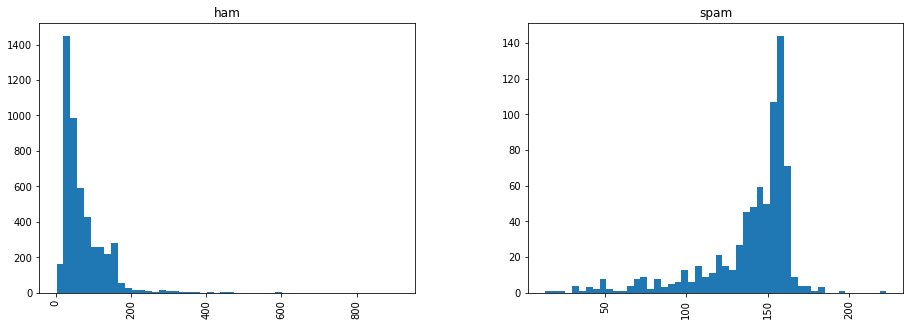

```python
msg.hist(column='length',by='label',bins=50,figsize=(15,5))
```

## Step 4: Data Cleaning and Preparation (Text Preprocessing)

The text data need to be cleaned before we use that to train the model. Let us do the below to extract significant words:

1. Remove puctuations
2. Remove stopwords

```python
"""
1. Remove punc
2. Remove stopwords
3. Return clean text words  list
"""
from nltk.corpus import stopwords
import string
#nltk.download('stopwords')

def text_process(msg):
    nopunc = [char for char in msg if char not in string.punctuation]
    nopunc = ''.join(nopunc)
    return [word for word in nopunc.split() if word.lower() not in stopwords.words('english')]

msg['msgs'].head(3).apply(text_process)
```

```
0    [Go, jurong, point, crazy, Available, bugis, n...
1                       [Ok, lar, Joking, wif, u, oni]
2    [Free, entry, 2, wkly, comp, win, FA, Cup, fin...
Name: msgs, dtype: object
```

```python
msg['msgs']=msg['msgs'].apply(text_process)
```

```python
msg['msgs'].tail()
```

```
5567    [2nd, time, tried, 2, contact, u, U, £750, Pou...
5568                   [ü, b, going, esplanade, fr, home]
5569                     [Pity, mood, Soany, suggestions]
5570    [guy, bitching, acted, like, id, interested, b...
5571                                   [Rofl, true, name]
Name: msgs, dtype: object
```

## Step 5: Train & Test Data Preparation

Now we need to split the data to train & test sets which can be used to build and evaluate the model

```python
from sklearn.model_selection import train_test_split
msg_train,msg_test,label_train,label_test = train_test_split(msg['msgs'],msg['label'],test_size=0.3,random_state=78)
```

## Step 6: Using pipeline feature in sklearn to build the model¶

```python
from sklearn.pipeline import Pipeline
from sklearn.feature_extraction.text import CountVectorizer
from sklearn.feature_extraction.text import TfidfTransformer
from sklearn.naive_bayes import MultinomialNB
from sklearn.metrics import classification_report,confusion_matrix
# CountVectorizer= Used to convert text to numeric and forms a Term frequency Matrix
# TDIDFTransformer= Used to find the weightage for Unique words then multiply with TF
# MultinomialNB= Used to Train the TF*IDF vector using Naive Bayes classifier
pipeline = Pipeline([
    ('bow', CountVectorizer(analyzer=text_process)),
    ('tfidf', TfidfTransformer()),
    ('classifier', MultinomialNB()),
])
```

```python
pipeline.fit(msg_train,label_train)
```

```
Pipeline(memory=None,
     steps=[('bow', CountVectorizer(analyzer=<function text_process at 0x000002175BF09158>,
        binary=False, decode_error='strict', dtype=<class 'numpy.int64'>,
        encoding='utf-8', input='content', lowercase=True, max_df=1.0,
        max_features=None, min_df=1, ngram_range=(1, 1), preprocesso...f=False, use_idf=True)), ('classifier', MultinomialNB(alpha=1.0, class_prior=None, fit_prior=True))])
```

```python
predictions = pipeline.predict(msg_test)
print(confusion_matrix(predictions,label_test))
print(classification_report(predictions,label_test))
```

```
[[1438  233]
 [   0    1]]
              precision    recall  f1-score   support

         ham       1.00      0.86      0.93      1671
        spam       0.00      1.00      0.01         1

   micro avg       0.86      0.86      0.86      1672
   macro avg       0.50      0.93      0.47      1672
weighted avg       1.00      0.86      0.92      1672
```

Naive Baye's algorithm failed to detect the spam messages

## Step 7: Using KNN Just to predict the accuracy

```python
from sklearn.neighbors import KNeighborsClassifier
pipeline1 = Pipeline([
    ('bow', CountVectorizer(analyzer=text_process)),
    ('tfidf', TfidfTransformer()),
    ('classifier', KNeighborsClassifier()),
])
pipeline1.fit(msg_train,label_train)
```

```
Pipeline(memory=None,
     steps=[('bow', CountVectorizer(analyzer=<function text_process at 0x000002175BF09158>,
        binary=False, decode_error='strict', dtype=<class 'numpy.int64'>,
        encoding='utf-8', input='content', lowercase=True, max_df=1.0,
        max_features=None, min_df=1, ngram_range=(1, 1), preprocesso...ki',
           metric_params=None, n_jobs=None, n_neighbors=5, p=2,
           weights='uniform'))])
```

```python
predictions1 = pipeline1.predict(msg_test)
print(confusion_matrix(predictions1,label_test))
print(classification_report(predictions1,label_test))
```

```
[[1438  233]
 [   0    1]]
              precision    recall  f1-score   support

         ham       1.00      0.86      0.93      1671
        spam       0.00      1.00      0.01         1

   micro avg       0.86      0.86      0.86      1672
   macro avg       0.50      0.93      0.47      1672
weighted avg       1.00      0.86      0.92      1672
```

Even the KNN fails to detect the spam messages, Next most efficient algorithm is Decision tree

## Step 8: Using Decision Tree

```python
from sklearn.tree import DecisionTreeClassifier
#dtree = DecisionTreeClassifier()
pipeline2 = Pipeline([
    ('bow', CountVectorizer(analyzer=text_process)),
    ('tfidf', TfidfTransformer()),
    ('classifier', DecisionTreeClassifier()),
])
pipeline2.fit(msg_train,label_train)
```

```
Pipeline(memory=None,
     steps=[('bow', CountVectorizer(analyzer=<function text_process at 0x000002175BF09158>,
        binary=False, decode_error='strict', dtype=<class 'numpy.int64'>,
        encoding='utf-8', input='content', lowercase=True, max_df=1.0,
        max_features=None, min_df=1, ngram_range=(1, 1), preprocesso...      min_weight_fraction_leaf=0.0, presort=False, random_state=None,
            splitter='best'))])
```

```python
predictions2 = pipeline2.predict(msg_test)
print(confusion_matrix(predictions2,label_test))
print(classification_report(predictions2,label_test))
```

```
[[1438  182]
 [   0   52]]
              precision    recall  f1-score   support

         ham       1.00      0.89      0.94      1620
        spam       0.22      1.00      0.36        52

   micro avg       0.89      0.89      0.89      1672
   macro avg       0.61      0.94      0.65      1672
weighted avg       0.98      0.89      0.92      1672
```

## Step 9: Added few new spam datasets to existing datasets

```python
#df = pd.read_csv('F:\pythonProject\Vignesh Programming\Spam Detector\\test1.csv',encoding='ISO-8859–1')
msg1=pd.read_csv('F:\pythonProject\Vignesh Programming\Spam Detector\\add.txt',sep='\t',names=['label','msgs'])
msg1.head()
```

|  | label | msgs |
| --- | --- | --- |
| 0 | spam | Urgent! call 09061749602 from Landline. Your c... |
| 1 | spam | +449071512431 URGENT! This is the 2nd attempt ... |
| 2 | spam | FREE for 1st week! No1 Nokia tone 4 ur mob eve... |
| 3 | spam | Urgent! call 09066612661 from landline. Your c... |
| 4 | spam | WINNER!! As a valued network customer you have... |

## Repeating Step 3-8 again with newly added datasets

```python
#Visualization
msg1['length']=msg1['msgs'].apply(len)
msg1.head()
```

|  | label | msgs | length |
| --- | --- | --- | --- |
| 0 | spam | Urgent! call 09061749602 from Landline. Your c... | 149 |
| 1 | spam | +449071512431 URGENT! This is the 2nd attempt ... | 163 |
| 2 | spam | FREE for 1st week! No1 Nokia tone 4 ur mob eve... | 158 |
| 3 | spam | Urgent! call 09066612661 from landline. Your c... | 168 |
| 4 | spam | WINNER!! As a valued network customer you have... | 158 |

```python
msg1['length'].describe()
```

```
count    5654.000000
mean       81.366112
std        60.026449
min         2.000000
25%        36.000000
50%        63.000000
75%       125.000000
max       910.000000
Name: length, dtype: float64
```

```
array([<matplotlib.axes._subplots.AxesSubplot object at 0x000002175F31A1D0>,
      dtype=object)
```

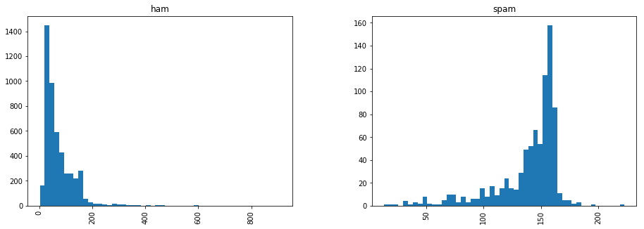

```python
msg1.hist(column='length',by='label',bins=50,figsize=(15,5))
```

```python
#data cleaning and preprocessing
def text_process(msg):
    nopunc = [char for char in msg if char not in string.punctuation]
    nopunc = ''.join(nopunc)
    return [word for word in nopunc.split() if word.lower() not in stopwords.words('english')]

#msg1['msgs'].head(3).apply(text_process)
```

```python
msg1['msgs']=msg1['msgs'].apply(text_process)
msg1['msgs'].head()
```

```
0    [Urgent, call, 09061749602, Landline, complime...
1    [449071512431, URGENT, 2nd, attempt, contact, ...
2    [FREE, 1st, week, No1, Nokia, tone, 4, ur, mob...
3    [Urgent, call, 09066612661, landline, compleme...
4    [WINNER, valued, network, customer, selected, ...
Name: msgs, dtype: object
```

```python
#Train and test split
msg_train,msg_test,label_train,label_test = train_test_split(msg1['msgs'],msg1['label'],test_size=0.3,random_state=78)
(label_test== 'spam').head(20)
```

```
1357    False
4821    False
5038    False
3115    False
2904    False
3658    False
653     False
2536    False
5451    False
2317    False
2746     True
5621    False
2987    False
251     False
4988     True
317      True
5500    False
5234    False
1765    False
441     False
Name: label, dtype: bool
```

```python
# Naive bayes

# CountVectorizer= Used to convert text to numeric and forms a Term frequency Matrix
# TDIDFTransformer= Used to find the weightage for Unique words then multiply with TF
# MultinomialNB= Used to Train the TF*IDF vector using Naive Bayes classifier
pipeline = Pipeline([
    ('bow', CountVectorizer(analyzer=text_process)),
    ('tfidf', TfidfTransformer()),
    ('classifier', MultinomialNB()),
])

pipeline.fit(msg_train,label_train)
predictions = pipeline.predict(msg_test)
print(confusion_matrix(predictions,label_test))
print(classification_report(predictions,label_test))
```

```
[[1449  242]
 [   0    6]]
              precision    recall  f1-score   support

         ham       1.00      0.86      0.92      1691
        spam       0.02      1.00      0.05         6

   micro avg       0.86      0.86      0.86      1697
   macro avg       0.51      0.93      0.49      1697
weighted avg       1.00      0.86      0.92      1697
```

```python
pipeline1 = Pipeline([
    ('bow', CountVectorizer(analyzer=text_process)),
    ('tfidf', TfidfTransformer()),
    ('classifier', KNeighborsClassifier()),
])
pipeline1.fit(msg_train,label_train)
predictions1 = pipeline1.predict(msg_test)
print(confusion_matrix(predictions1,label_test))
print(classification_report(predictions1,label_test))
```

```
[[1449  242]
 [   0    6]]
              precision    recall  f1-score   support

         ham       1.00      0.86      0.92      1691
        spam       0.02      1.00      0.05         6

   micro avg       0.86      0.86      0.86      1697
   macro avg       0.51      0.93      0.49      1697
weighted avg       1.00      0.86      0.92      1697
```

```python
#Using Decision tree

pipeline2 = Pipeline([
    ('bow', CountVectorizer(analyzer=text_process)),
    ('tfidf', TfidfTransformer()),
    ('classifier', DecisionTreeClassifier()),
])
pipeline2.fit(msg_train,label_train)

predictions2 = pipeline2.predict(msg_test)
print(confusion_matrix(predictions2,label_test))
print(classification_report(predictions2,label_test))
```

```
[[1449  191]
 [   0   57]]
              precision    recall  f1-score   support

         ham       1.00      0.88      0.94      1640
        spam       0.23      1.00      0.37        57

   micro avg       0.89      0.89      0.89      1697
   macro avg       0.61      0.94      0.66      1697
weighted avg       0.97      0.89      0.92      1697
```

[output not shown]